# 一,数据处理

- 缺省值处理(**Default handle**):  
  所用数据中,目标特征发现有几例缺省值,数量较少,故剔除

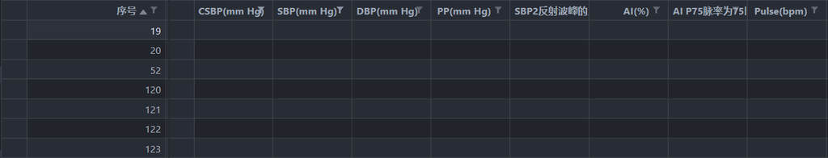

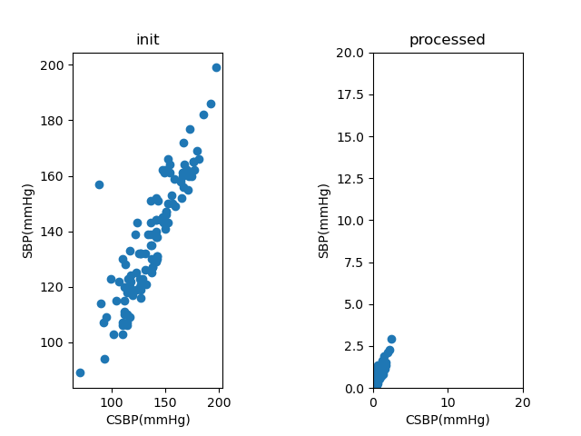

# 二,聚类过程

- 确认最优聚类数目K:  
  使用卡林斯基-哈拉巴斯指数进行对聚类效果的评估,当簇内差异越小,簇间差异越大时,该指数就越大,根据分析不同k值的指数,得出突变点k=2聚类效果最好

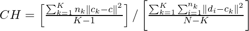

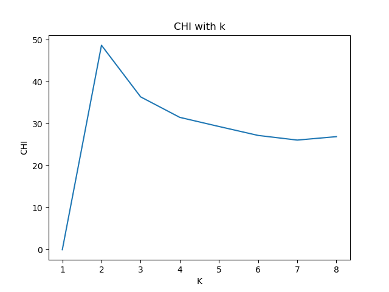

- 簇中心的选取: 使用了两种簇中心初始化方法,一种是随机初始化,另一种是kmeans++的初始化方法,效果相同

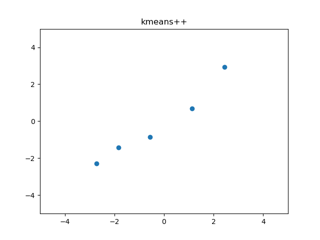

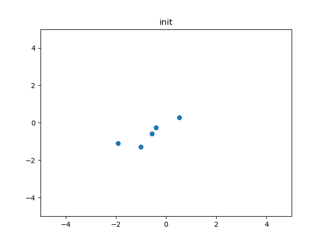

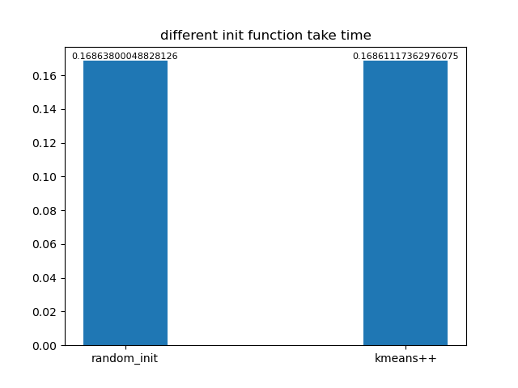

- 聚类的算法过程:  
  使用欧式距离确定簇中心
- 终止:  
  迭代终止或者这一轮的簇中心与上一轮簇中心一致则停止迭代

# 三,评估

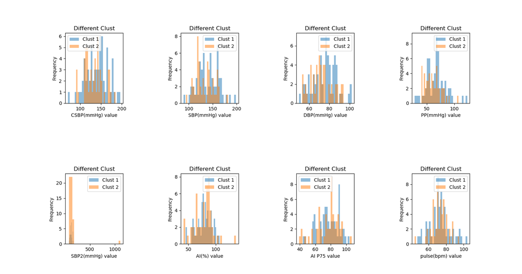

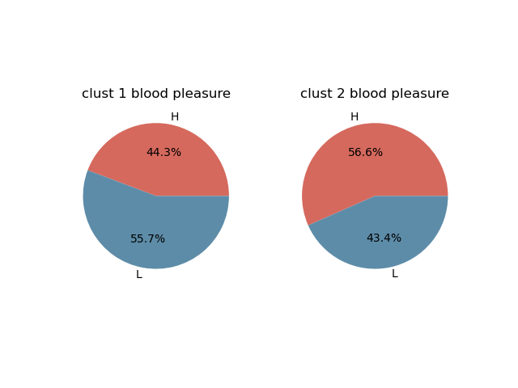